# Lung_Infection_local

## Following operations should be performed using Keras or PyTorch or Torch vision-

### Import the necessary libraries

```python
from tensorflow.keras import layers, optimizers, models, losses
from tensorflow.keras.preprocessing.image import ImageDataGenerator
from tensorflow.keras.callbacks import EarlyStopping

#from tensorflow.keras.applications.densenet import preprocess_input

import matplotlib.pyplot as plt
from PIL import Image
```

```python
# from google.colab import drive
# drive.mount('/content/drive')
```

### Plot the sample images for all the classes

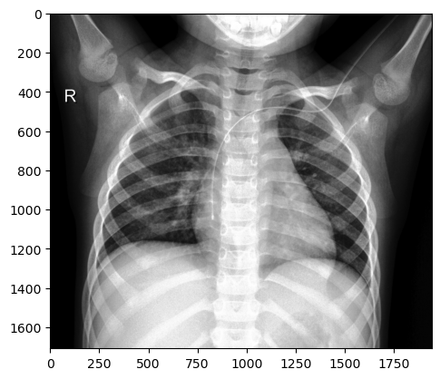

```python
healthy_img = Image.open('../../Datasets/Lung_Infection/train/Healthy/01.jpeg')
plt.imshow(healthy_img)
```

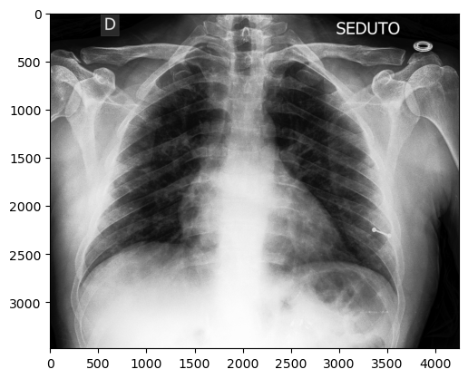

```python
Type_1_img = Image.open('../../Datasets/Lung_Infection/train/Type 1 disease/01.jpeg')
plt.imshow(Type_1_img)
```

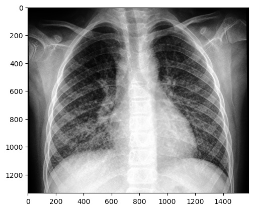

```python
Type_2_img = Image.open('../../Datasets/Lung_Infection/train/Type 2 disease/01.jpeg')
plt.imshow(Type_2_img)
```

### Plot the distribution of images across the classes

```
{'Healthy': 70, 'Type 1 disease': 111, 'Type 2 disease': 70}
```

```
<BarContainer object of 3 artists>
```

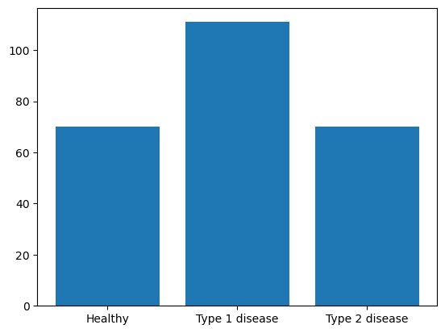

```python
import os

path = '../../Datasets/Lung_Infection/train/'
class_dist = {}
count = 0

for i in os.listdir(path):
  flag = 0
  for j in os.listdir(path+i+'/'):
    if(flag == 0):
      class_dist[i] = 1
      flag = 1
    else:
      class_dist[i] += 1
print(class_dist)
plt.bar(class_dist.keys(),[class_dist[i] for i in class_dist.keys()])
#plt.bar(class_dist.keys(),[class_dist['Healthy'],class_dist['Type 1 disease'], class_dist['Type 2 disease']])
```

```python
test_image = ImageDataGenerator(rescale=1/255.,
                                horizontal_flip = True,
                                vertical_flip = True,
                                rotation_range=35)
```

```python
train_image = ImageDataGenerator(rescale=1/255.,
                                horizontal_flip=True,
                                vertical_flip = True,
                                rotation_range=35)
```

### Read images directly from the train folder and test folder using the appropriate function

```python
trainImageset = train_image.flow_from_directory('../../Datasets/Lung_Infection/train',target_size=(224,224),batch_size=4)
testImageset = test_image.flow_from_directory('../../Datasets/Lung_Infection/test',target_size=(224,224),batch_size=4)
```

```
Found 251 images belonging to 3 classes.
Found 66 images belonging to 3 classes.
```

## Build 3 CNN model with:

### 2. Use Relu as an activation function

```python
def convModel():
    model = models.Sequential()

    model.add(layers.Conv2D(16,(3,3),input_shape=trainImageset.image_shape,activation='relu',padding='same'))
    model.add(layers.Conv2D(16,(3,3),activation='relu',padding='same'))
    model.add(layers.MaxPool2D(pool_size=(2,2)))

    model.add(layers.Conv2D(32,(3,3),activation='relu',padding='same'))
    model.add(layers.Conv2D(32,(3,3),activation='relu',padding='same'))
    model.add(layers.MaxPool2D(pool_size=(2,2)))

    model.add(layers.Conv2D(64,(3,3),activation='relu',padding='same'))
    model.add(layers.Conv2D(64,(3,3),activation='relu',padding='same'))
    model.add(layers.MaxPool2D(pool_size=(2,2)))

    model.add(layers.Conv2D(128,(3,3),activation='relu',padding='same'))
    model.add(layers.Conv2D(128,(3,3),activation='relu',padding='same'))
    model.add(layers.MaxPool2D(pool_size=(2,2)))

    model.add(layers.Conv2D(256,(3,3),activation='relu',padding='same'))
    model.add(layers.Conv2D(256,(3,3),activation='relu',padding='same'))
    model.add(layers.MaxPool2D(pool_size=(2,2)))

    model.add(layers.Flatten())

    model.add(layers.Dense(64,activation='relu'))
    model.add(layers.Dense(64,activation='relu'))
    model.add(layers.Dense(len(trainImageset.class_indices.keys()),activation='softmax'))

    return model
```

### 3. Take the loss function as categorical cross-entropy

### 4. Take rmsprop as an optimizer

### 5. Use early stopping with the patience of two epochs and monitor the validation loss or accuracy

```python
model = convModel()
callback = EarlyStopping(monitor='val_accuracy',patience=2, min_delta = 0 )
model.compile(loss='categorical_crossentropy',optimizer='rmsprop', metrics=['accuracy'])
model.summary()
```

```
Model: "sequential_2"
_________________________________________________________________
Layer (type)                 Output Shape              Param #
=================================================================
conv2d_20 (Conv2D)           (None, 224, 224, 16)      448
_________________________________________________________________
conv2d_21 (Conv2D)           (None, 224, 224, 16)      2320
_________________________________________________________________
max_pooling2d_10 (MaxPooling (None, 112, 112, 16)      0
_________________________________________________________________
conv2d_22 (Conv2D)           (None, 112, 112, 32)      4640
_________________________________________________________________
conv2d_23 (Conv2D)           (None, 112, 112, 32)      9248
_________________________________________________________________
max_pooling2d_11 (MaxPooling (None, 56, 56, 32)        0
_________________________________________________________________
conv2d_24 (Conv2D)           (None, 56, 56, 64)        18496
_________________________________________________________________
conv2d_25 (Conv2D)           (None, 56, 56, 64)        36928
_________________________________________________________________
max_pooling2d_12 (MaxPooling (None, 28, 28, 64)        0
_________________________________________________________________
conv2d_26 (Conv2D)           (None, 28, 28, 128)       73856
_________________________________________________________________
conv2d_27 (Conv2D)           (None, 28, 28, 128)       147584
_________________________________________________________________
max_pooling2d_13 (MaxPooling (None, 14, 14, 128)       0
_________________________________________________________________
conv2d_28 (Conv2D)           (None, 14, 14, 256)       295168
_________________________________________________________________
conv2d_29 (Conv2D)           (None, 14, 14, 256)       590080
_________________________________________________________________
max_pooling2d_14 (MaxPooling (None, 7, 7, 256)         0
_________________________________________________________________
flatten_3 (Flatten)          (None, 12544)             0
_________________________________________________________________
dense_7 (Dense)              (None, 64)                802880
_________________________________________________________________
dense_8 (Dense)              (None, 64)                4160
_________________________________________________________________
dense_9 (Dense)              (None, 3)                 195
=================================================================
Total params: 1,986,003
Trainable params: 1,986,003
Non-trainable params: 0
_________________________________________________________________
```

### 6. Try with ten numbers epoch

### 7. Train the model using a generator and test the accuracy of the test data at every epoch

```python
model_hist = model.fit(trainImageset,epochs=10,validation_data=testImageset,callbacks=[callback])
```

### 8. Plot the training and validation accuracy, and the loss

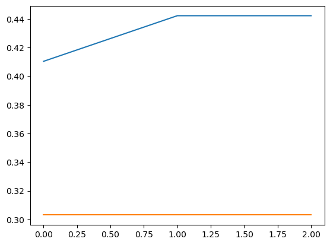

```python
plt.plot(model_hist.history["accuracy"])
plt.plot(model_hist.history["val_accuracy"])
plt.show()
```

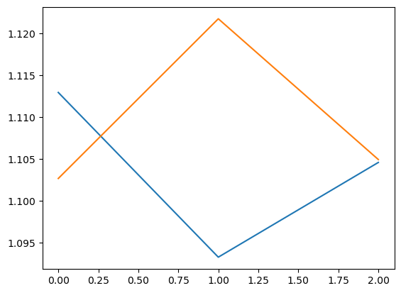

```python
plt.plot(model_hist.history["loss"])
plt.plot(model_hist.history["val_loss"])
plt.show()
```

```python
testImageset.labels
```

```
array([0, 0, 0, 0, 0, 0, 0, 0, 0, 0, 0, 0, 0, 0, 0, 0, 0, 0, 0, 0, 0, 0,
       0, 0, 0, 0, 1, 1, 1, 1, 1, 1, 1, 1, 1, 1, 1, 1, 1, 1, 1, 1, 1, 1,
       1, 1, 2, 2, 2, 2, 2, 2, 2, 2, 2, 2, 2, 2, 2, 2, 2, 2, 2, 2, 2, 2],
      dtype=int32)
```

### 9. Observe the precision, recall the F1-score for all classes for both grayscale and color models, and determine if the model’s classes are good

```python
from sklearn.metrics import f1_score, recall_score, precision_score
import numpy as np

y_preds = model.predict(testImageset)
```

```python
CNN_metrices = {}
```

```python
CNN_metrices['precision'] = precision_score(testImageset.labels,y_preds.argmax(axis=1),average='weighted')
```

```python
CNN_metrices['f1'] = f1_score(testImageset.labels,y_preds.argmax(axis=1),average='weighted')
```

```python
CNN_metrices['recall'] = recall_score(testImageset.labels,y_preds.argmax(axis=1),average='weighted')
```

## 2 Transfer learning using mobile net:

```python
from tensorflow.keras.applications.mobilenet import MobileNet
from tensorflow.keras.applications.mobilenet import preprocess_input
```

### 1. Prepare data for the pre-trained mobile net model, with color mode as RGB

```python
train_image_mobilenet = ImageDataGenerator(rescale = 1/255.0, preprocessing_function=preprocess_input)
test_image_mobilenet = ImageDataGenerator(rescale = 1/255.0, preprocessing_function=preprocess_input)
```

```python
trainImageset = train_image_mobilenet.flow_from_directory('../../Datasets/Lung_Infection/train',
                                                target_size=(224,224),
                                                color_mode = 'rgb',
                                                batch_size=1
                                                )
testImageset = test_image_mobilenet.flow_from_directory('../../Datasets/Lung_Infection/test',
                                              target_size=(224,224),
                                              color_mode = 'rgb',
                                              batch_size=1
                                              )
```

```
Found 251 images belonging to 3 classes.
Found 66 images belonging to 3 classes.
```

### 2. Create an instance of a mobile net pre-trained model

```python
base_model = MobileNet(input_shape=trainImageset.image_shape ,weights='imagenet',include_top = False)
x=base_model.output
```

### 3. Add dense layer, dropout layer, batch normalization layer on the pre-trained model

### 4. Create a final output layer with a SoftMax activation function

```python
x = layers.Flatten()(x)
x = layers.Dense(4096,activation='relu')(x)
x = layers.BatchNormalization()(x)
x = layers.Dropout(0.2)(x)
#x = layers.Dense(2048,activation='relu')(x)
predict = layers.Dense(3,activation='softmax')(x)

model = models.Model(inputs=base_model.input,outputs=predict)
```

[output not shown]

[output not shown]

[output not shown]

### 5. Change the batch size activation function and optimize as rmsprop and observe if the accuracy increases

### 6. Take the loss function as categorical cross-entropy

```python
callback = EarlyStopping(monitor='val_Accuracy',patience=2, min_delta = 0 )
model.compile(optimizer='rmsprop',loss='categorical_crossentropy',metrics=['Accuracy'])
model.summary()
```

### 7. Use early stopping with the patience of two epoch and call back function for preventing overfitting

### 8. Try with ten numbers epoch

### 9. Train the model using a generator and test the accuracy of the test data at every epoch

```python
model_hist = model.fit(trainImageset,epochs=10,validation_data=testImageset,callbacks=[callback])
```

### 10. Plot the training and validation accuracy, and the loss

```python
plt.plot(model_hist.history['Accuracy'])
plt.plot(model_hist.history['val_Accuracy'])
plt.show()
```

[output not shown]

```python
plt.plot(model_hist.history['loss'])
plt.plot(model_hist.history['val_loss'])
plt.show()
```

[output not shown]

### 11. Observe the precision, recall the F1-score for all classes for both grayscale and color models, and determine if the model’s classes are good

```python
from sklearn.metrics import f1_score, recall_score, precision_score
import numpy as np

y_preds = model.predict(testImageset)
```

```python
mobilenet_metrices = {}
```

```python
mobilenet_metrices['precision'] = precision_score(testImageset.labels,y_preds.argmax(axis=1),average='weighted')
```

```python
mobilenet_metrices['f1'] = f1_score(testImageset.labels,y_preds.argmax(axis=1),average='weighted')
```

```python
mobilenet_metrices['recall'] = recall_score(testImageset.labels,y_preds.argmax(axis=1),average='weighted')
```

## 3. Transfer Learning using Densenet121:

### 1. Prepare the dataset for the transfer learning algorithm using Densenet121 with the image size as 224x224x3

```python
from tensorflow.keras.applications.densenet import DenseNet121
from tensorflow.keras.applications.densenet import preprocess_input
```

```python
train_image_densenet = ImageDataGenerator(rescale=1/255.,preprocessing_function=preprocess_input)
test_image_densenet = ImageDataGenerator(rescale=1/255.,preprocessing_function=preprocess_input)
```

```python
train_imageset_densenet = train_image_densenet.flow_from_directory('../../Datasets/Lung_Infection/train',
                                                                   target_size=(224,224))
test_imageset_densenet = test_image_densenet.flow_from_directory('.././Datasets/Lung_Infection/test',
                                                                   target_size=(224,224))
```

```python
densenet_base_model = DenseNet121(input_shape=train_imageset_densenet.image_shape,include_top=False)
```

```python
densenet_base_model.layers[0].trainable = False
```

### 3. Add a dense layer at the end of the pre-trained model followed by a dropout layer and try various combinations to get an accuracy

### 4. Add the final output layer with a SoftMax activation function

```python
x = densenet_base_model.output
x = layers.Flatten()(x)
x = layers.Dense(1024,activation='relu')(x)
x = layers.Dropout(0.2)(x)
#x = layers.Dense(1024,activation='relu')(x)
densenet_predict = layers.Dense(3,activation='softmax')(x)

model = models.Model(inputs=densenet_base_model.input,outputs=densenet_predict)
```

### 5. Take loss function as categorical cross-entropy

### 6. Take Adam as an optimizer

### 7. Use early stopping to prevent overfitting

```python
callback = EarlyStopping(monitor='val_accuracy',patience=2, min_delta = 0 )
model.compile(optimizer='ADAM',loss='categorical_crossentropy',metrics=['accuracy'])
model.summary()
```

### 9. Train the model using the generator and test the accuracy of the test data at every epoch

```python
model_hist_densenet = model.fit(train_imageset_densenet,epochs=15,validation_data=test_imageset_densenet,callbacks= [callback])
```

### 10. Plot the training and validation accuracy, and the loss

```python
plt.plot(model_hist_densenet.history['accuracy'])
plt.plot(model_hist_densenet.history['val_accuracy'])
plt.show()
```

[output not shown]

```python
plt.plot(model_hist_densenet.history['loss'])
plt.plot(model_hist_densenet.history['val_loss'])
plt.show()
```

[output not shown]

### 11. Observe the precision, recall the F1-score for all classes for both grayscale and color models, and determine if the model’s classes are good

```python
from sklearn.metrics import f1_score, recall_score, precision_score
import numpy as np

y_preds = model.predict(test_imageset_densenet)
```

```python
densenet_metrices = {}
```

```python
densenet_metrices['precison'] = precision_score(test_imageset_densenet.labels,y_preds.argmax(axis=1),average='weighted')
```

```python
densenet_metrices['f1']= f1_score(test_imageset_densenet.labels,y_preds.argmax(axis=1),average='weighted')
```

```python
densenet_metrices['recall'] = recall_score(test_imageset_densenet.labels,y_preds.argmax(axis=1),average='weighted')
```

## Final step:

```python
plt.bar(CNN_metrices.keys(),[CNN_metrices[i] for i in CNN_metrices.keys()])
```

[output not shown]

```python
plt.bar(mobilenet_metrices.keys(),[mobilenet_metrices[i] for i in mobilenet_metrices.keys()])
```

[output not shown]

```python
plt.bar(densenet_metrices.keys(),[densenet_metrices[i] for i in densenet_metrices.keys()])
```

[output not shown]